[High Frequency Trading](https://github.com/scibrokes/real-time-fxcm)

[®γσ, Lian Hu](https://englianhu.github.io/)®

2018-10-22

```r
#'@ rm(list = ls(all = TRUE))

suppressPackageStartupMessages(library('BBmisc'))
pkgs <- c('devtools', 'knitr', 'kableExtra', 'tint', 'devtools', 'lubridate', 'data.table', 'quantmod', 'shiny', 'R.utils', 'memoise', 'magrittr', 'plyr', 'dplyr', 'stringr', 'purrr', 'TFX', 'TTR', 'quantmod', 'tidyquant', 'tibbletime', 'furrr', 'QuantTools', 'Quandl', 'FinancialInstrument', 'foreach', 'RTAQ', 'rugarch', 'tidyverse', 'htmltools', 'highcharter', 'googleVis', 'formattable', 'DT', 'reticulate', 'highfrequency', 'HighFreq', 'EventStudy')

if(!require('QuantTools')){
  devtools::install_bitbucket('quanttools/QuantTools')
}
require('QuantTools')

if(!require('blotter')){
  devtools::install_github("braverock/blotter") # dependency
}
require('blotter')

if(!require('quantstrat')){
  devtools::install_github("braverock/quantstrat")
}
require('blotter')
# https://stackoverflow.com/questions/44891437/install-quantstrat-for-r-latest-r-version
# https://r-forge.r-project.org/R/?group_id=316

suppressAll(lib(pkgs))
#funs <- c('plotChart2.R', 'read_tick.data.R')
#l_ply(paste0('./function/', funs), source)

cr_code <- c('AUDUSD=X', 'EURUSD=X', 'GBPUSD=X', 'CHF=X', 'CAD=X',
             'CNY=X', 'JPY=X')

names(cr_code) <- c('AUDUSD', 'EURUSD', 'GBPUSD', 'USDCHF', 'USDCAD',
                    'USDCNY', 'USDJPY')

## https://www.alphavantage.co/
## https://www.alphavantage.co/support/#api-key
api = 'UL7EPVVEGDVC3TXC'

options(warn = -1)
rm(pkgs)
```

# 1 Introduction

## 1.1 Introduce High Frequency Trading

High frequency trading is an automated trading platform used by large investment banks, hedge funds and institutional investors which utilizes powerful computers to transact a large number of orders at extremely high speeds. These high frequency trading platforms allow traders to execute millions of orders and scan multiple markets and exchanges in a matter of seconds, thus giving the institutions that use the platforms a huge advantage in the open market.

Read more: [What is high-frequency trading?](http://www.investopedia.com/ask/answers/09/high-frequency-trading.asp#ixzz4wVO6j7e4)

## 1.2 Introduce Relevant Papers

By refer to *Ryo Eng Lian Hu (2017)*[^1], I tried to compare few Kelly funds for financial trading.

*Understanding the Kelly Capital Growth Investment Strategy* describe that the suggestion fractional Kelly for high frequency trading is low due to nowadays all quantitative are programmed trading. Professor William Ziemba describe that the founder of PIMCO fund probably using Kelly model since he used to read the <<*Beat the Dealers*>> where introduce the Kelly criterion model. The *6.2 Correction in Next Paper* inside *binary.com Interview Question I - Tick-Data-HiLo For Daily Trading* (Blooper) propose a dynamic fractional Kelly model where $0.5 \leq f \leq 1$ and perhaps will in [Application of Kelly Criterion model in Sportsbook Investment](https://github.com/scibrokes/kelly-criterion).

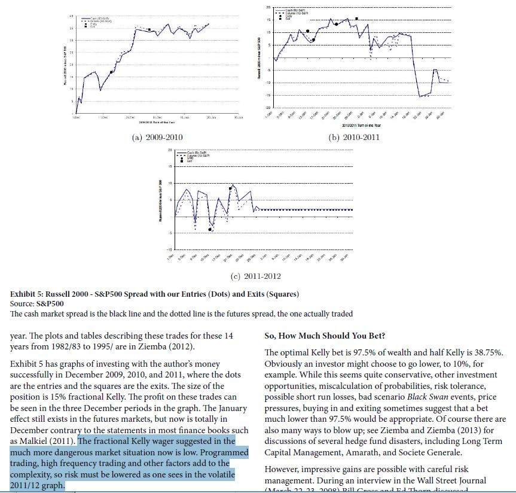

*Financial Risk Modelling and Portfolio Optimization with R (2nd Edt)* and *如何用R语言开始量化投资* introduce some useful r packages for quantitative trading. *原则 - 雷·达里奥* is the autobiography of Ray Dalio, he describe how he use the quantitative modelling and $\alpha$ model to evaluate the risk and invest. Besides, he also introduce how to manage his $160 billion world leading Bridgewater hedge fund .[^2] This paper is not talk about management while you can try to refer to [Analyse the Finance and Stocks Price of Bookmakers](https://github.com/scibrokes/analyse-the-finance-and-stocks-price-of-bookmakers) will touch about the financial statement and stock price.

*解密复兴科技 - 基于隐蔽马尔科夫模型的时序分析方法* decode the World number 1’s profitable statistical model. The *Markov Hidden Model* and *Autoregressive Markov Switching Model* will be most interest and will start study in another paper. I was think of using HMM or bernoulli distribution to determine the value $f$ for dynamic fractional Kelly.

[Hidden Markov Mdel](https://community.rstudio.com/t/hidden-markov-mdel/13741) and [Getting Started with Hidden Markov Models in R](http://blog.revolutionanalytics.com/2014/03/r-and-hidden-markov-models.html) introduce HMM model.

*binary.com Interview Question I - Interday High Frequency Trading* suggest a better model for interday trading, *binary.com Interview Question I - Multivariate GARCH Models* compares the multivariate GARCH models. Now I try to fit the high-frequency univariate model into multivariate model for intraday trading.

[Convert multivariate XTS to TS in R](https://stackoverflow.com/questions/44250867/convert-multivariate-xts-to-ts-in-r) using `wavethresh` package.